# Learning rates paper

Preliminary results 2 - Not for publication!

# Results for PV – in lead currency USD & with BNEF marketshare

Here, we present an improved approach that uses global market shares (in this document based on data from BNEF) and a correction factor to calculate a global learning rate that is the same over all currencies. We chose 6 relevant currencies (CNY, EUR, GBP, INR, JPY, USD) and calculate a learning rate between 2006 and 2016. We look only at PV projects above 5 MW.

# Data

## Load and prepare BNEF data

Our analysis is based on the Bloomberg New Energy Finance (BNEF) renewable energy database. The dataset is copyright protected and can not be shared. We use the BNEF dataset because it gives investment costs for individual installations and projects in the original currencies, or allows for conversion to the domestic currency of each project. We subset the data according to different criteria, as seen below.

```r
data_projects <- read_csv(
    file = "input/data_PV_all_nominal.csv",
    col_types = cols(
      `Financing Date` = col_date(format="%Y-%m-%d")),
    na = c("","NA")) %>%
  select(
    id = `Renewable Project ID`,
    capacity = `Capacity - total (MWe)`,
    total_local_value = `Total Value (Local)`,
    local_currency_long = `Local Currency`,
    country = Country,
    date = `Financing Date`,
    status = Status)
commissioned_projects <- filter(
    data_projects,
    status == "Commissioned")
relevant_projects <- filter(
    commissioned_projects,
    capacity >= params$capacity_threshold,
    !is.na(date))
non_relevant_projects1 <- filter(
    commissioned_projects,
    capacity < params$capacity_threshold)
non_relevant_projects2 <- filter(
    commissioned_projects,
    capacity >= params$capacity_threshold,
    is.na(date))
```

The BNEF dataset does not consistenly report the original, local currencies. In cases where the local currency is missing, we assumed that projects were financed in the main currency of the corresponding project countries. In addition, I transform from total local value in Millions to local value in currency/W.

In addition, we consistently use the short ISO currency codes. Hence we convert the long currency codes to short ones.

| id | capacity | total_local_value | local_currency_long | country | date | status | local_currency_short | local_currency_added | local_currency_final | local_value | year |
| --- | --- | --- | --- | --- | --- | --- | --- | --- | --- | --- | --- |
| 139173 | 28.00 | 113000.00 | South Korean Won | Japan | 2016-04-20 | Commissioned | Other | JPY | Other | 4035.7142857 | 2016 |
| 119140 | 6.80 | 17.00 | United States Dollar | Japan | 2015-11-30 | Commissioned | USD | JPY | USD | 2.5000000 | 2015 |
| 819 | 5.00 | 27.00 | United States Dollar | Germany | 2004-01-20 | Commissioned | USD | EUR | USD | 5.4000000 | 2004 |
| 95136 | 30.00 | 24.76 | United States Dollar | India | 2016-07-31 | Commissioned | USD | INR | USD | 0.8253333 | 2016 |
| 105427 | 12.00 | 10.75 | United States Dollar | India | 2015-02-14 | Commissioned | USD | INR | USD | 0.8958333 | 2015 |
| 28438 | 75.00 | 221.00 | Euro | India | 2011-08-11 | Commissioned | EUR | INR | EUR | 2.9466667 | 2011 |
| 99977 | 7.00 | 8.40 | United States Dollar | India | 2015-04-01 | Commissioned | USD | INR | USD | 1.2000000 | 2015 |
| 120746 | 40.00 | 36.00 | United States Dollar | India | 2016-05-11 | Commissioned | USD | INR | USD | 0.9000000 | 2016 |
| 6163 | 7.80 | 55.38 | United States Dollar | Spain | 2006-11-29 | Commissioned | USD | EUR | USD | 7.1000000 | 2006 |
| 11741 | 5.80 | 41.53 | United States Dollar | Spain | 2008-09-30 | Commissioned | USD | EUR | USD | 7.1603448 | 2008 |

[output cut: 8 more lines]

| id | date | capacity | local_currency | local_value | year |
| --- | --- | --- | --- | --- | --- |
| 120958 | 2016-07-09 | 40.00 | CNY | 8.300000 | 2016 |
| 113561 | 2017-01-01 | 20.00 | CNY | 8.000000 | 2017 |
| 70992 | 2016-03-30 | 10.00 | CNY | 8.300000 | 2016 |
| 54580 | 2012-06-20 | 20.00 | CNY | 13.250000 | 2012 |
| 54582 | 2013-06-19 | 20.00 | CNY | 10.000000 | 2013 |
| 128937 | 2016-10-26 | 20.00 | CNY | 8.000000 | 2016 |
| 56830 | 2012-07-03 | 20.00 | CNY | 11.170000 | 2012 |
| 71970 | 2013-10-09 | 30.00 | CNY | 10.000000 | 2013 |
| 128179 | 2013-10-25 | 30.00 | CNY | 10.692667 | 2013 |
| 102220 | 2014-10-28 | 20.00 | CNY | 8.500000 | 2014 |

[output cut: 990 more lines]

| description | projects | project.share | capacity | capacity.share |
| --- | --- | --- | --- | --- |
| all | 22987 | NA | 516698.76 | NA |
| all commissioned | 14250 | 1.00 | 188910.95 | 1.00 |
| all relevant | 7363 | 0.52 | 173188.44 | 0.92 |
| all relevant with costs and outliers | 2174 | 0.15 | 62230.49 | 0.33 |
| all relevant with costs | 2165 | 0.15 | 62100.29 | 0.33 |

The BNEF dataset contains a total of 22987 PV projects, of which 14250 are commissioned. Of those commissioned projects, we consider 7363 as relevant because they have a capacity of >= 5 MW, which is an indication that their local-cost component is low. Among the comissioned projects, some are not relevant (to caluclate learning rates) because they are either below that threshold (6670), above but miss a financing date record (210) or are reported in other, minor currencies.

Finally, only **2165 projects** have a financing costs in one of the relevant currencies. We use these projects , i.e. 32.9% of worldwide capacity to calculate the learning rates.These numbers and the corresponding capacity they represent are sumarised in the table below.

## Load and prepare IRENA data

We also use the IREAN dataset to calculate market shares, if the paramater is set. The IRENA data better represent the market shares than the BNEF data. For the calculations of the learning rates we need curreny information that the IRENA dataset does not include. Hence, we assume that the projects were financed in the main currency of the corresponding countries.

## Exchange rates

Exchange rates are from OFX and OECD, and the defaltors are based on OECD Consumer Price Index (CPI) data.

## Cummulative sums

X is the global cumulative deployment in year t -> cummulative sum of x_global (sum of xj) per year I always use the cummulative capacity from BNEF because it relates to the average costs and projects.

# Learning rate calculations

## Method 1: Simple learning rates in different currencies

We calculate the simple learning rate in multiple steps.

### Step 1: Calculation of costs in every relevant currency

1. we add columns for every relevant currency to the data.frame.
2. For each project, we calculate the value of the lead currency (default USD) from the local value and an exchange rate that is close to the project date.
3. We caluculate the values in each relevant currency from the (in step 2 calculates) lead currency value.

| id | date | capacity | local_currency | local_value | year | CNY | EUR | GBP | INR | JPY | USD |
| --- | --- | --- | --- | --- | --- | --- | --- | --- | --- | --- | --- |
| 120958 | 2016-07-09 | 40.00 | CNY | 8.300000 | 2016 | 8.300000 | 1.1637700 | 0.8756861 | 84.90892 | 149.53717 | 1.2625423 |
| 113561 | 2017-01-01 | 20.00 | CNY | 8.000000 | 2017 | 8.000000 | 1.0910427 | 0.9392289 | 78.95700 | 133.45934 | 1.1597617 |
| 70992 | 2016-03-30 | 10.00 | CNY | 8.300000 | 2016 | 8.300000 | 1.1637700 | 0.8756861 | 84.90892 | 149.53717 | 1.2625423 |
| 54580 | 2012-06-20 | 20.00 | CNY | 13.250000 | 2012 | 13.250000 | 1.6258827 | 1.3531746 | 107.71966 | 161.46488 | 2.0979132 |
| 54582 | 2013-06-19 | 20.00 | CNY | 10.000000 | 2013 | 10.000000 | 1.1976952 | 0.9965036 | 86.50927 | 141.68488 | 1.5926798 |
| 128937 | 2016-10-26 | 20.00 | CNY | 8.000000 | 2016 | 8.000000 | 1.1217060 | 0.8440348 | 81.83992 | 144.13221 | 1.2169083 |
| 56830 | 2012-07-03 | 20.00 | CNY | 11.170000 | 2012 | 11.170000 | 1.3706498 | 1.1407517 | 90.80970 | 136.11794 | 1.7685804 |
| 71970 | 2013-10-09 | 30.00 | CNY | 10.000000 | 2013 | 10.000000 | 1.1976952 | 0.9965036 | 86.50927 | 141.68488 | 1.5926798 |
| 128179 | 2013-10-25 | 30.00 | CNY | 10.692667 | 2013 | 10.692667 | 1.2806556 | 1.0655281 | 92.50148 | 151.49892 | 1.7029994 |
| 102220 | 2014-10-28 | 20.00 | CNY | 8.500000 | 2014 | 8.500000 | 1.0222470 | 0.8455175 | 86.44385 | 144.75558 | 1.3925487 |

[output cut: 990 more lines]

### Step 2. Aggregate data to means

We no aggregate the data by yearly averages. average_global_costs are the aggregated means of all(!) projects (no subset)

### Step 3. Convert to real values (in 2017 units)

### Step 4. Calculation of learning rates

```
[1] "Calc LR with simple methods in currency  CNY in interval 2006-2011"
[1] 90.62679 88.59472 88.25849 41.27628 38.30955 25.79844
[1]  157.74  466.44  918.30 1420.65 2908.11 6537.81
[1] "Calc LR with simple methods in currency  CNY in interval 2012-2016"
[1] 17.225392 13.864454 11.773800 10.169209  9.880632
[1] 11821.04 19572.76 29681.09 45152.81 57004.24
[1] "Calc LR with simple methods in currency  CNY in interval 2006-2016"
 [1] 90.626791 88.594725 88.258487 41.276283 38.309555 25.798437 17.225392
 [8] 13.864454 11.773800 10.169209  9.880632
 [1]   157.74   466.44   918.30  1420.65  2908.11  6537.81 11821.04 19572.76
 [9] 29681.09 45152.81 57004.24
[1] "Calc LR with simple methods in currency  EUR in interval 2006-2011"
[1] 8.039814 7.782868 7.546910 4.130315 3.599556 2.752825
[1]  157.74  466.44  918.30 1420.65 2908.11 6537.81
[1] "Calc LR with simple methods in currency  EUR in interval 2012-2016"
```

[output cut: 51 more lines]

[output not shown]

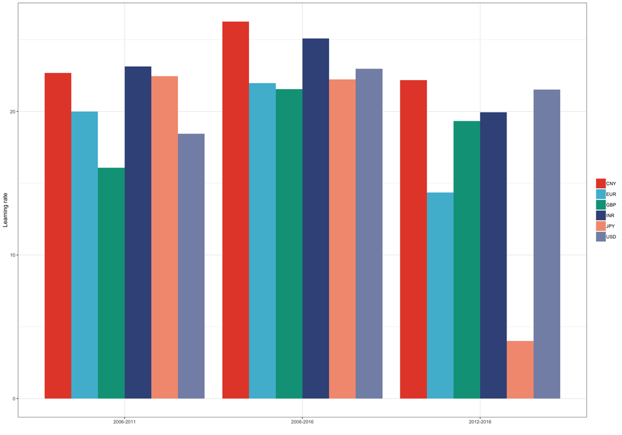

## Method 2: Currency-corrected learning rates

A detailed explanation of the theory behind the currency-corrected learning rates is in Bjarnes note.

### Step 1: Marketshare calculation

In this method, the marketshares are not included in the global means. Instead, they are extracted first. In this section, I use two types of market share calculation. Once from the orignal data and from IRENA. The IRENA data represent global market shares more accurately.

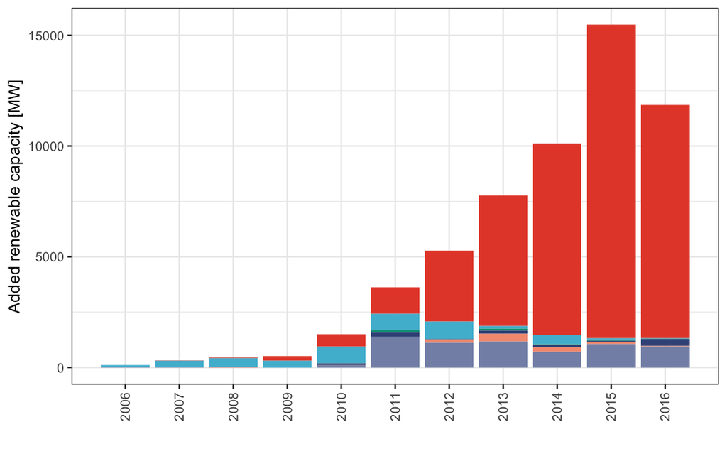

#### Marketshare plots (BNEF)

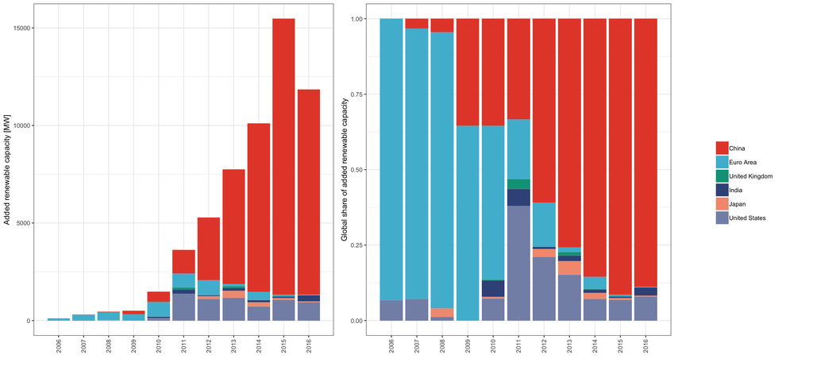

| original currency | currency area | year | deployment in currency (x) | sum of deployments | share (delta) |
| --- | --- | --- | --- | --- | --- |
| CNY | China | 2006 | 0.00 | 115.74 | 0.0000000000 |
| CNY | China | 2009 | 178.10 | 502.35 | 0.3545336916 |
| CNY | China | 2015 | 14142.41 | 15471.72 | 0.9140813045 |
| CNY | China | 2013 | 5875.47 | 7751.72 | 0.7579569437 |
| CNY | China | 2011 | 1210.66 | 3629.70 | 0.3335427170 |
| CNY | China | 2014 | 8639.84 | 10108.33 | 0.8547247666 |
| CNY | China | 2007 | 10.00 | 308.70 | 0.0323939099 |
| CNY | China | 2010 | 527.30 | 1487.46 | 0.3544969276 |
| CNY | China | 2016 | 10520.13 | 11851.43 | 0.8876675642 |
| CNY | China | 2012 | 3217.22 | 5283.23 | 0.6089494495 |

[output cut: 56 more lines]

### Step 2: Calculation of the formula variable

C are observed average cost in currency i. We use the variable average_local_costs

```
       CNY EUR GBP INR JPY USD
  2002   1   1   1   1   1   1
  2004   1   1   1   1   1   1
  2005   1   1   1   1   1   1
  2006   1   1   1   1   1   1
  2007   1   1   1   1   1   1
  2008   1   1   1   1   1   1
  2009   1   1   1   1   1   1
  2010   1   1   1   1   1   1
  2011   1   1   1   1   1   1
  2012   1   1   1   1   1   1
  2013   1   1   1   1   1   1
  2014   1   1   1   1   1   1
  2015   1   1   1   1   1   1
  2016   1   1   1   1   1   1
  2017   1   1   1   1   1   1
```

The table shows which currency have average_local_costs in which year.

### Step 3: Calculation of the weighted average global

Because there is exchange rate data for each month, I select a month based on the exchangerate_reference_month parameter

### Step 4: Calculate learning rate

[output not shown]

[output not shown]

# Appendix

## Calculation

### calculation of currency-corrected learning rates

We calculate our improved currency-corrected learning rate in the lead currency **USD** The resulting, single learning rate is based on the *weighted average global cost converted to lead currency* $P_{t,2017}^l$. We derive $P_{t,2017}^l$ by:

1. calculating $C_{t}^{i}$, i.e. the yearly means of all costs reported in currency i (a subset of all costs).
2. weighting the (nominal) average costs $C_{t}^{i}$ in each year $t$ by the market share in year $t$.
3. converting the weighted average costs to the lead currency.
4. taking the sum of all weighted costs in the lead.
5. applying a deflator to get the (real) 2017 costs.

The theoretical input paper by Bjarne describes the calculations in more detail.

### Calculation of Simple learning rates in different currencies

To calculate the simple learning rates, we convert **all available project costs** to different currencies. We then derive the learning rate for each currency from the global average costs $C_{global,t,2017}^{i}$ of all available projects. We derive $C_{global,t,2017}^{i}$ for each year $t$ and currency $i$ by

1. converting all project costs (N = 2165) to currency $i$,
2. aggretating these costs (in currency $i$) to yearly means and by
3. applying a deflator to get the (real) 2017 costs.

## Data

### Exchangerates and deflators

Exchange rates are from OFX and OECD, and the defaltors are based on OECD Consumer Price Index (CPI) data.

## Handling of missing currency data in the datasets

The marketshare (i.e. deltas) are based on the currency information of different projects (e.g. USD, EUR). However, some BNEF and all IRENA projects lacked this information. Instead they were reported on a country-specific basis. To derive the necessary currency information, we applied some data transformations.

Based on the assumption that all projects reported in country X are financed in the main currency x of X, we complemented the corresponding projects X with currency x. Our assumption is justified by an inital data exploration that shows that this correlation holds true for most projects that had the currency information in the first place.

## Linear Regression and learning rate calculation

To derive the learning curves, we applied a single-factor learning curve as defined in (Lindman and Söderholm 2012):

$ln(C_t) = \beta_0 + \beta_1 \cdot ln(CC_t).$

with, $C_t$ as the cost at time $t$, $CC_t$ as cummulative capacity at time $t$, and $\beta_0$ and $\beta_1$ as linear regression estimates. The learning rates is then derived from $\beta_1$:

$LR = 1 - 2^{\beta_1}.$

Based on these formulas, we applied a linear regression model with OLS (Ordinary Least Squares) over the transformed data (with ln-ln transformation of the predictors, as visible in the first formula).

# Literature

Lindman, Åsa, and Patrik Söderholm. 2012. “Wind power learning rates: A conceptual review and meta-analysis.” *Energy Economics* 34 (3): 754–61.